# Investigate_a_dataset

## Project: Exploratory Data Analysis of No Show Appointment Dataset

The dataset used for this project is the No-show appointments dataset. The csv file 'noshowappointments-kagglev2-may-2016.csv' is stored in the same location as the 'Investigate_a_dataset.ipynb' file.

## Research Questions

Following research questions were selected for this project.

1. What factors are important for us to know if a patient will show up for their scheduled appointment?
2. Do patients show up more if appointments are scheduled on weekends or weekdays?
3. Does waiting time i.e. ScheduledDay - AppointmentDay lead to no shows?
- Introduction
- Data Wrangling
- Exploratory Data Analysis
- Conclusions

## Introduction

In this section, I have imported all packages that will be used in the entire project. Dataset has been loaded to a Pandas dataframe. I have also used the info() function to view basic information about the dataset.

```python
#Importing packages necessary for analyzing the dataset
import pandas as pd
import numpy as np
import matplotlib.pyplot as plt
import seaborn as sns
import datetime
import time
% matplotlib inline
```

```python
#Reading the csv file in a Pandas dataframe
noshowappointments_df = pd.read_csv('noshowappointments-kagglev2-may-2016.csv')
```

```python
#Exploring the first 5 lines of the dataset.
noshowappointments_df.head()
```

|  | PatientId | AppointmentID | Gender | ScheduledDay | AppointmentDay | Age | Neighbourhood | Scholarship | Hipertension | Diabetes | Alcoholism | Handcap | SMS_received | No-show |
| --- | --- | --- | --- | --- | --- | --- | --- | --- | --- | --- | --- | --- | --- | --- |
| 0 | 2.987250e+13 | 5642903 | F | 2016-04-29T18:38:08Z | 2016-04-29T00:00:00Z | 62 | JARDIM DA PENHA | 0 | 1 | 0 | 0 | 0 | 0 | No |
| 1 | 5.589978e+14 | 5642503 | M | 2016-04-29T16:08:27Z | 2016-04-29T00:00:00Z | 56 | JARDIM DA PENHA | 0 | 0 | 0 | 0 | 0 | 0 | No |
| 2 | 4.262962e+12 | 5642549 | F | 2016-04-29T16:19:04Z | 2016-04-29T00:00:00Z | 62 | MATA DA PRAIA | 0 | 0 | 0 | 0 | 0 | 0 | No |
| 3 | 8.679512e+11 | 5642828 | F | 2016-04-29T17:29:31Z | 2016-04-29T00:00:00Z | 8 | PONTAL DE CAMBURI | 0 | 0 | 0 | 0 | 0 | 0 | No |
| 4 | 8.841186e+12 | 5642494 | F | 2016-04-29T16:07:23Z | 2016-04-29T00:00:00Z | 56 | JARDIM DA PENHA | 0 | 1 | 1 | 0 | 0 | 0 | No |

The below cell describes basic information about the data set. The noshowappointments_df data frame has 110,527 rows and 14 columns. It can also be seen that none of the columns have null values.

```python
noshowappointments_df.info()
```

```
<class 'pandas.core.frame.DataFrame'>
RangeIndex: 110527 entries, 0 to 110526
Data columns (total 14 columns):
PatientId         110527 non-null float64
AppointmentID     110527 non-null int64
Gender            110527 non-null object
ScheduledDay      110527 non-null object
AppointmentDay    110527 non-null object
Age               110527 non-null int64
Neighbourhood     110527 non-null object
Scholarship       110527 non-null int64
Hipertension      110527 non-null int64
Diabetes          110527 non-null int64
Alcoholism        110527 non-null int64
Handcap           110527 non-null int64
SMS_received      110527 non-null int64
No-show           110527 non-null object
dtypes: float64(1), int64(8), object(5)
memory usage: 11.8+ MB
```

## Data Wrangling

In this section, I am exploring columns of the dataframe and cleaning it to get it ready for further exploratory data analaysis.

The data set has no duplicate values.

```python
#Checked for any duplicate values in the dataset.
sum(noshowappointments_df.duplicated())
```

```
0
```

```python
#Checking values of mean, standard deviation and max age for patients as it is a numeric value
noshowappointments_df['Age'].describe()
```

```
count    110527.000000
mean         37.088874
std          23.110205
min          -1.000000
25%          18.000000
50%          37.000000
75%          55.000000
max         115.000000
Name: Age, dtype: float64
```

Age is a numeric column and hence looked at the descriptive statistics for Age column. It can be seen that minimum value for Age is -1 and maximum value is 115. This shows that there are outliers in the dataset and they need to be handled properly.

```python
#Checking if AppointmentIDs are unique. PatientIDs are not unique and have visited more than once.
noshowappointments_df.nunique()
```

```
PatientId          62299
AppointmentID     110527
Gender                 2
ScheduledDay      103549
AppointmentDay        27
Age                  104
Neighbourhood         81
Scholarship            2
Hipertension           2
Diabetes               2
Alcoholism             2
Handcap                5
SMS_received           2
No-show                2
dtype: int64
```

Dropped the row that had Age value as -1 and plotted a box plot to look at outliers for Age in the dataset.

```python
#Dropping the row that has Age as -1 and 100 and above.
noshowappointments_df.drop(noshowappointments_df[noshowappointments_df['Age'] == -1].index, inplace = True)
```

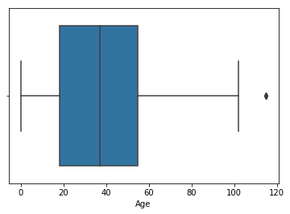

```python
#This boxplot for Age column shows that Age column has outliers and it needs to be removed from the dataset.
#It seems as there are a few outliers near the Age between 110 and 120.
#Removing the rows where Age > 115. These are Outliers and need to be removed from the dataset.
sns.boxplot(x = noshowappointments_df['Age'])
```

The above box plot shows values where Age is greater than 110 which is an outlier. As the number of datapoints is relatively small compared to the size of the dataset, I decided to drop these values and reset the index.

```python
#Removing all values for which Age > 115
indexNames = noshowappointments_df[noshowappointments_df['Age'] > 110].index

# Delete these row indexes from noshowappointments_df dataframe as need to eliminate these 5 outliers
noshowappointments_df.drop(indexNames , inplace=True)
```

```python
#Resetting indices after dropping some rows from the dataset
noshowappointments_df = noshowappointments_df.reset_index()
```

The ScheduledDay and AppointmentDay columns need to be converted to a datetime format. I have also added a new column called waiting_time which is the difference in days between the Scheduled Day and Appointment Day.

```python
#Converting ScheduledDay column to DateTime format
noshowappointments_df['scheduled_day'] = pd.to_datetime(noshowappointments_df['ScheduledDay'], format='%Y-%m-%dT%H:%M:%SZ')
#Converting AppointmentDay to DateTime format
noshowappointments_df['appointment_day'] = pd.to_datetime(noshowappointments_df['AppointmentDay'], format='%Y-%m-%dT%H:%M:%SZ')

noshowappointments_df['waiting_time'] = round((noshowappointments_df['scheduled_day'] - noshowappointments_df['appointment_day'])/np.timedelta64(1,'D'),0)
noshowappointments_df['waiting_time'] = abs(noshowappointments_df['waiting_time'].astype('int'))
```

```python
noshowappointments_df.groupby('No-show').size()
```

```
No-show
No     88205
Yes    22316
dtype: int64
```

The above row shows that about 20% of the appointments resulted in no shows. It is important to understand which features are affecting the number of no shows. In this dataset, no-show is the dependent variable while other features such as Gender, Scholarship, Hypertension, Diabetes, Alcoholism, Handcap, SMS received, Scheduled Day, Waiting time are all independent variables that can have an affect on number of no shows.

```python
#Checking unique values for other columns

print(noshowappointments_df['Gender'].unique())
print(noshowappointments_df['Scholarship'].unique())
print(noshowappointments_df['Hipertension'].unique())
print(noshowappointments_df['Diabetes'].unique())
print(noshowappointments_df['Alcoholism'].unique())

print(noshowappointments_df['Handcap'].unique())
print(noshowappointments_df['SMS_received'].unique())
```

```
['F' 'M']
[0 1]
[1 0]
[0 1]
[0 1]
[0 1 2 3 4]
[0 1]
```

```python
#After noticing that Handcap column has values such as 2, 3 and 4 they were grouped as category 1 i.e. Handcap = Yes
#0 -> No
#1 -> Yes
noshowappointments_df.groupby('Handcap').size()
```

```
Handcap
0    108284
1      2038
2       183
3        13
4         3
dtype: int64
```

```python
#There are 199 rows with values 2 3 and 4 for Handcap column.
#Assigning them as 1 as Handcap is a boolean value.
def clean_handcap():
    for i in range(len(noshowappointments_df)):
        if noshowappointments_df['Handcap'].iloc[i] > 1:
            noshowappointments_df['Handcap'].iloc[i] = 1
```

```python
clean_handcap()
```

```python
noshowappointments_df.groupby('Handcap').size()
```

```
Handcap
0    108284
1      2237
dtype: int64
```

```python
#Converting PatientId from float to string format
noshowappointments_df['PatientId'] = noshowappointments_df['PatientId'].astype('int').astype('str')
```

```python
noshowappointments_df.head()
```

|  | index | PatientId | AppointmentID | Gender | ScheduledDay | AppointmentDay | Age | Neighbourhood | Scholarship | Hipertension | Diabetes | Alcoholism | Handcap | SMS_received | No-show | scheduled_day | appointment_day | waiting_time |
| --- | --- | --- | --- | --- | --- | --- | --- | --- | --- | --- | --- | --- | --- | --- | --- | --- | --- | --- |
| 0 | 0 | 29872499824296 | 5642903 | F | 2016-04-29T18:38:08Z | 2016-04-29T00:00:00Z | 62 | JARDIM DA PENHA | 0 | 1 | 0 | 0 | 0 | 0 | No | 2016-04-29 18:38:08 | 2016-04-29 | 1 |
| 1 | 1 | 558997776694438 | 5642503 | M | 2016-04-29T16:08:27Z | 2016-04-29T00:00:00Z | 56 | JARDIM DA PENHA | 0 | 0 | 0 | 0 | 0 | 0 | No | 2016-04-29 16:08:27 | 2016-04-29 | 1 |
| 2 | 2 | 4262962299951 | 5642549 | F | 2016-04-29T16:19:04Z | 2016-04-29T00:00:00Z | 62 | MATA DA PRAIA | 0 | 0 | 0 | 0 | 0 | 0 | No | 2016-04-29 16:19:04 | 2016-04-29 | 1 |
| 3 | 3 | 867951213174 | 5642828 | F | 2016-04-29T17:29:31Z | 2016-04-29T00:00:00Z | 8 | PONTAL DE CAMBURI | 0 | 0 | 0 | 0 | 0 | 0 | No | 2016-04-29 17:29:31 | 2016-04-29 | 1 |
| 4 | 4 | 8841186448183 | 5642494 | F | 2016-04-29T16:07:23Z | 2016-04-29T00:00:00Z | 56 | JARDIM DA PENHA | 0 | 1 | 1 | 0 | 0 | 0 | No | 2016-04-29 16:07:23 | 2016-04-29 | 1 |

```python
#Renaming values of 0 -> No and 1 -> Yes as they are binary values
noshowappointments_df['Scholarship'] = noshowappointments_df['Scholarship'].replace({0 : 'No', 1 : 'Yes'})
noshowappointments_df['Hipertension'] = noshowappointments_df['Hipertension'].replace({0 : 'No', 1 : 'Yes'})
noshowappointments_df['Diabetes'] = noshowappointments_df['Diabetes'].replace({0 : 'No', 1 : 'Yes'})
noshowappointments_df['Alcoholism'] = noshowappointments_df['Alcoholism'].replace({0 : 'No', 1 : 'Yes'})
noshowappointments_df['Handcap'] = noshowappointments_df['Handcap'].replace({0 : 'No', 1 : 'Yes'})
noshowappointments_df['SMS_received'] = noshowappointments_df['SMS_received'].replace({0 : 'No', 1 : 'Yes'})
```

```python
#Dropping columns that are not important for our analysis
noshowappointments_df.drop(['AppointmentID'], axis = 1, inplace = True)
noshowappointments_df.drop(['ScheduledDay'], axis = 1, inplace = True)
noshowappointments_df.drop(['AppointmentDay'], axis = 1, inplace = True)
```

```python
#Create a new column "Age Group" which bins the "Age" column
# 0 - 12 : Child
# 13 - 19 : Teenager
# 20 - 30 : Young Adult
# 31- 60: Adults
# > 60 : Elders

bin_edges = [0, 12, 19, 30, 60, 110]
bin_names = ['Child', 'Teenager', 'Young Adult', 'Adult', 'Elderly']

noshowappointments_df['age_group'] = pd.cut(noshowappointments_df['Age'], bin_edges, labels=bin_names)
```

```python
noshowappointments_df = noshowappointments_df.rename(columns = {"PatientId": "patient_id",
                                  "Gender":"gender",
                                  "Age": "age",
                                  "Neighbourhood": "neighbourhood",
                                  "Scholarship": "scholarship",
                                  "Hipertension": "hipertension",
                                  "Diabetes" : "diabetes",
                                  "Alcoholism": "alcoholism",
                                  "Handcap" : "handicap",
                                  "SMS_received" : "sms_received",
                                  "scheduled_day" : "scheduled_day",
                                  "appointment_day" : "appointment_day",
                                  "waiting_time" : "waiting_time",
                                  "age_group" : "age_group",
                                  "No-show": "no-show"})
```

```python
#Categorize waiting days in the following groups
# 0 days -> Same day
# 1 - 7 days -> 1 Week
# 8 - 30 days - > 1 week
# 30 - 60 days -> 1 - 2 months
# 60 - 90 days -> 2 - 3 months
# 90 - 180 days -> > 3 -6 months
bin_edges = [1, 7, 30, 60, 90, 180]
bin_names = ['1 Week', '2 - 3 Weeks', '1 - 2 Months', '2 - 3 Months', '3 - 6 Months']

noshowappointments_df['waiting_time_category'] = pd.cut(noshowappointments_df['waiting_time'], bin_edges, labels=bin_names)
```

```python
noshowappointments_df['waiting_time_category']  = noshowappointments_df['waiting_time_category'].cat.add_categories('Same Day')
noshowappointments_df['waiting_time_category'].fillna('Same Day', inplace =True)
```

```python
noshowappointments_df.groupby('waiting_time_category').size()
```

```
waiting_time_category
1 Week          25486
2 - 3 Weeks     28689
1 - 2 Months     8023
2 - 3 Months     1880
3 - 6 Months      186
Same Day        46257
dtype: int64
```

```python
#Adding a new column to the dataset that describes Day of the week for Scheduled Day column
noshowappointments_df['day_of_week'] = noshowappointments_df['scheduled_day'].dt.weekday_name
```